# mirror_exp_rescored

Allison Davis

October 25, 2019

# Self inspection/ Mirror experiment

## Overview/Purpose

#### *Purpose*

Bilateral vision allows organisms to specialize their vision/visual tasks in order to perform more efficiently. Fish use their bilateral vision to more effeciently shoal/school, inspect predators, find food, and mate. In addition to aiding in each individual task, lateralization can help multitask (e.g. feed and watch for predators). The self inspection/mirror experiment test which visual field (left or right) fish prefer to use in the identification/assessment of a **conspecific.** Here we not only tested for difference in preference, but differences in the amount of variation between sexual sailfin mollies and asexual amazon mollies.

#### *General Methods*

Used two tanks (arbitrarily labled A and B). Long walls of both tanks had acrylic mirror; short walls had white corrugated poster board. Fish were placed in tank for 5min acclimation followed by a 10min swim period, in which we recorded their visual use. Occurances of left or right visual use were determined by scoring every 2sec of video, starting at second 10 and ending at minute 10. This gave 296 occurance values (left, right, or NA for no direct lateralized use). Preference scores calculated as: left/(left+right). A total of 16 Amazon mollies (P. form) and 13 sailfin mollies (P. lat) went through this experiment. *[as of 13 August 2019]* A total of 20 Amazon mollies (P.form) and 20 sailfin mollies (P.lat) went through this experiment. *[as of 3 September 2019]* *For rescored data*: Previously, preference was determined by angle towards closest mirror; if the fish was closest to bottom mirror but angled with face towards top mirror, this was determined as NA. To rescore, I went through all the NAs and determined eye use towards any mirror (previous example was determined left or right in regards to eye use on top mirror). Any NAs still remaining are of positions in which the fish is perpendicular to the mirror (facing it head on).

## Data collection

- raw data: occurance number and preference score for each individual fish (left, right, NA)
- pref data: preference scores for tank A, B, combo of A and B, and average of A and B
  - combo score determined as left/(left+right) for total left and right occurances
  - average score determined by averaging tank A pref score and tank B pref score

```r
library(curl)

rawRE <- curl("https://raw.githubusercontent.com/allisondavis/mirror-exp_wild-pop/master/adavis_mirror-exp_wild-pop_rescored-raw.csv")

rawRE <- read.csv(rawRE, header = TRUE, sep = ",", stringsAsFactors = TRUE)

prefRE <- curl("https://raw.githubusercontent.com/allisondavis/mirror-exp_wild-pop/master/adavis_mirror-exp_wild-pop_rescored-prefs.csv")

prefRE <- read.csv(prefRE, header = TRUE, sep = ",", stringsAsFactors = TRUE)

head(rawRE)
```

```
##   X.U.FEFF.SPP    NAME A.LEFT A.RIGHT A.NA    A.PROP B.LEFT B.RIGHT B.NA
## 1        P.lat Beijing    172     109   15 0.6120996    147     149    0
## 2        P.lat  Camila    129     151   16 0.4607143    136     158    2
## 3        P.lat Jessica    171     123    2 0.5816327    104     182   10
## 4        P.lat  London    157     128   11 0.5508772    119     167   10
## 5        P.lat Melissa    127     164    5 0.4364261    157     129   10
## 6        P.lat   Paris    130     153   13 0.4593640    150     143    3
##      B.PROP TOT.LEFT TOT.RIGHT TOT.NA  TOT.PROP  AVG.PROP  X X.1 X.2 X.3
## 1 0.4966216      319       258     15 0.5528596 0.5543606 NA  NA  NA  NA
## 2 0.4625850      265       309     18 0.4616725 0.4616497 NA  NA  NA  NA
## 3 0.3636364      275       305     12 0.4741379 0.4726345 NA  NA  NA  NA
## 4 0.4160839      276       295     21 0.4833625 0.4834806 NA  NA  NA  NA
## 5 0.5489510      284       293     15 0.4922010 0.4926886 NA  NA  NA  NA
## 6 0.5119454      280       296     16 0.4861111 0.4856547 NA  NA  NA  NA
```

```r
head(prefRE)
```

```
##   X.U.FEFF.SPP    NAME    A.PROP    B.PROP  TOT.PROP  AVG.PROP
## 1        P.lat Beijing 0.6120996 0.4966216 0.5528596 0.5543606
## 2        P.lat  Camila 0.4607143 0.4625850 0.4616725 0.4616497
## 3        P.lat Jessica 0.5816327 0.3636364 0.4741379 0.4726345
## 4        P.lat  London 0.5508772 0.4160839 0.4833625 0.4834806
## 5        P.lat Melissa 0.4364261 0.5489510 0.4922010 0.4926886
## 6        P.lat   Paris 0.4593640 0.5119454 0.4861111 0.4856547
```

```r
#I will separate out the sexual vs asexual

p_form.rawRE <- rawRE[rawRE$X.U.FEFF.SPP =="P.form",]

p_lat.rawRE <- rawRE[rawRE$X.U.FEFF.SPP == "P.lat",]

p_formRE <- prefRE[prefRE$X.U.FEFF.SPP== "P.form",]
head(p_formRE)
```

```
##    X.U.FEFF.SPP    NAME    A.PROP    B.PROP  TOT.PROP  AVG.PROP
## 21       P.form     Kai 0.5252918 0.4864865 0.5058140 0.5058892
## 22       P.form   Maeve 0.4574468 0.4354839 0.4471698 0.4464653
## 23       P.form Cayenne 0.4631579 0.3321678 0.3975482 0.3976629
## 24       P.form   Freya 0.5587189 0.4532872 0.5052632 0.5060030
## 25       P.form     Ana 0.4680851 0.5226481 0.4956063 0.4953666
## 26       P.form  Ashley 0.6056338 0.5345455 0.5706619 0.5700896
```

```r
p_latRE <- prefRE[prefRE$X.U.FEFF.SPP== "P.lat",]
head(p_latRE)
```

```
##   X.U.FEFF.SPP    NAME    A.PROP    B.PROP  TOT.PROP  AVG.PROP
## 1        P.lat Beijing 0.6120996 0.4966216 0.5528596 0.5543606
## 2        P.lat  Camila 0.4607143 0.4625850 0.4616725 0.4616497
## 3        P.lat Jessica 0.5816327 0.3636364 0.4741379 0.4726345
## 4        P.lat  London 0.5508772 0.4160839 0.4833625 0.4834806
## 5        P.lat Melissa 0.4364261 0.5489510 0.4922010 0.4926886
## 6        P.lat   Paris 0.4593640 0.5119454 0.4861111 0.4856547
```

## Analyses

#### First glance

- These are just some summary statistics to get a feel for the data
  - Will use the raw data as it has everything included

```r
#P. latipinna

summary(p_lat.rawRE)
```

```
##  X.U.FEFF.SPP      NAME        A.LEFT         A.RIGHT           A.NA
##  P.form: 0    Amara  : 1   Min.   :113.0   Min.   :103.0   Min.   : 1.00
##  P.lat :20    Beijing: 1   1st Qu.:126.5   1st Qu.:118.5   1st Qu.: 6.00
##               Brielle: 1   Median :132.0   Median :136.5   Median :12.00
##               Camila : 1   Mean   :139.3   Mean   :139.2   Mean   :17.45
##               Cypress: 1   3rd Qu.:152.8   3rd Qu.:156.2   3rd Qu.:23.50
##               Elena  : 1   Max.   :182.0   Max.   :181.0   Max.   :55.00
##               (Other):14
##      A.PROP           B.LEFT         B.RIGHT           B.NA
##  Min.   :0.3844   Min.   :104.0   Min.   : 53.0   Min.   : 0.00
##  1st Qu.:0.4483   1st Qu.:133.8   1st Qu.:125.5   1st Qu.: 6.50
##  Median :0.4771   Median :148.5   Median :143.0   Median :10.00
##  Mean   :0.5012   Mean   :148.4   Mean   :135.5   Mean   :12.05
##  3rd Qu.:0.5659   3rd Qu.:156.2   3rd Qu.:150.0   3rd Qu.:11.50
##  Max.   :0.6276   Max.   :236.0   Max.   :182.0   Max.   :44.00
##
##      B.PROP          TOT.LEFT       TOT.RIGHT         TOT.NA
##  Min.   :0.3636   Min.   :222.0   Min.   :156.0   Min.   :11.00
##  1st Qu.:0.4674   1st Qu.:264.8   1st Qu.:257.2   1st Qu.:15.00
##  Median :0.5103   Median :282.0   Median :288.0   Median :20.00
##  Mean   :0.5226   Mean   :287.8   Mean   :274.8   Mean   :29.50
##  3rd Qu.:0.5556   3rd Qu.:301.2   3rd Qu.:298.2   3rd Qu.:33.75
##  Max.   :0.8166   Max.   :374.0   Max.   :322.0   Max.   :86.00
##
##     TOT.PROP         AVG.PROP         X             X.1
##  Min.   :0.4380   Min.   :0.4389   Mode:logical   Mode:logical
##  1st Qu.:0.4710   1st Qu.:0.4699   NA's:20        NA's:20
##  Median :0.4894   Median :0.4895
##  Mean   :0.5122   Mean   :0.5119
##  3rd Qu.:0.5504   3rd Qu.:0.5509
##  Max.   :0.7057   Max.   :0.6946
##
##    X.2            X.3
##  Mode:logical   Mode:logical
##  NA's:20        NA's:20
##
##
##
##
##
```

```r
(var_pl_RE <- apply(p_lat.rawRE[3:15],2,var))
```

```
##       A.LEFT      A.RIGHT         A.NA       A.PROP       B.LEFT
## 4.046421e+02 5.840921e+02 2.524711e+02 5.374337e-03 7.937342e+02
##      B.RIGHT         B.NA       B.PROP     TOT.LEFT    TOT.RIGHT
## 7.595263e+02 1.221553e+02 9.189058e-03 1.206092e+03 1.620092e+03
##       TOT.NA     TOT.PROP     AVG.PROP
## 5.180526e+02 4.314979e-03 4.106361e-03
```

```r
(std.dev_pl_RE <- apply(p_lat.rawRE[3:15], 2, sd))
```

```
##      A.LEFT     A.RIGHT        A.NA      A.PROP      B.LEFT     B.RIGHT
## 20.11571787 24.16799754 15.88933770  0.07330987 28.17328895 27.55950500
##        B.NA      B.PROP    TOT.LEFT   TOT.RIGHT      TOT.NA    TOT.PROP
## 11.05238722  0.09585958 34.72883680 40.25036777 22.76076957  0.06568850
##    AVG.PROP
##  0.06408089
```

```r
#P. formosa

summary(p_form.rawRE)
```

```
##  X.U.FEFF.SPP      NAME        A.LEFT         A.RIGHT           A.NA
##  P.form:20    Ana    : 1   Min.   :  5.0   Min.   :100.0   Min.   : 0.00
##  P.lat : 0    Ashley : 1   1st Qu.:132.0   1st Qu.:137.5   1st Qu.: 5.75
##               Ava    : 1   Median :141.0   Median :145.0   Median :11.00
##               Cayenne: 1   Mean   :135.5   Mean   :149.2   Mean   :11.30
##               Chloe  : 1   3rd Qu.:147.8   3rd Qu.:151.5   3rd Qu.:14.25
##               Dory   : 1   Max.   :183.0   Max.   :291.0   Max.   :39.00
##               (Other):14
##      A.PROP            B.LEFT         B.RIGHT           B.NA
##  Min.   :0.01689   Min.   : 95.0   Min.   :113.0   Min.   : 4.0
##  1st Qu.:0.46685   1st Qu.:138.0   1st Qu.:128.0   1st Qu.: 7.0
##  Median :0.49823   Median :144.0   Median :136.5   Median :11.0
##  Mean   :0.47728   Mean   :141.8   Mean   :138.9   Mean   :15.3
##  3rd Qu.:0.52048   3rd Qu.:148.5   3rd Qu.:146.2   3rd Qu.:18.0
##  Max.   :0.64664   Max.   :177.0   Max.   :191.0   Max.   :48.0
##
##      B.PROP          TOT.LEFT       TOT.RIGHT         TOT.NA
##  Min.   :0.3322   Min.   :150.0   Min.   :233.0   Min.   : 7.00
##  1st Qu.:0.4847   1st Qu.:273.0   1st Qu.:268.0   1st Qu.:12.50
##  Median :0.5108   Median :287.0   Median :281.0   Median :22.50
##  Mean   :0.5049   Mean   :277.3   Mean   :288.1   Mean   :26.60
##  3rd Qu.:0.5315   3rd Qu.:292.8   3rd Qu.:293.5   3rd Qu.:33.75
##  Max.   :0.6103   Max.   :324.0   Max.   :435.0   Max.   :76.00
##
##     TOT.PROP         AVG.PROP         X             X.1
##  Min.   :0.2564   Min.   :0.2593   Mode:logical   Mode:logical
##  1st Qu.:0.4898   1st Qu.:0.4898   NA's:20        NA's:20
##  Median :0.5055   Median :0.5059
##  Mean   :0.4910   Mean   :0.4911
##  3rd Qu.:0.5146   3rd Qu.:0.5147
##  Max.   :0.5794   Max.   :0.5779
##
##    X.2            X.3
##  Mode:logical   Mode:logical
##  NA's:20        NA's:20
##
##
##
##
##
```

```r
(var_pf_RE <- apply(p_form.rawRE[3:15], 2, var))
```

```
##       A.LEFT      A.RIGHT         A.NA       A.PROP       B.LEFT
## 1.197000e+03 1.430379e+03 6.874737e+01 1.505203e-02 3.200632e+02
##      B.RIGHT         B.NA       B.PROP     TOT.LEFT    TOT.RIGHT
## 2.832526e+02 1.381158e+02 3.326780e-03 1.543905e+03 1.916621e+03
##       TOT.NA     TOT.PROP     AVG.PROP
## 3.235158e+02 4.952816e-03 4.869397e-03
```

```r
(std.dev_pf_RE <- apply(p_lat.rawRE[3:15], 2, sd))
```

```
##      A.LEFT     A.RIGHT        A.NA      A.PROP      B.LEFT     B.RIGHT
## 20.11571787 24.16799754 15.88933770  0.07330987 28.17328895 27.55950500
##        B.NA      B.PROP    TOT.LEFT   TOT.RIGHT      TOT.NA    TOT.PROP
## 11.05238722  0.09585958 34.72883680 40.25036777 22.76076957  0.06568850
##    AVG.PROP
##  0.06408089
```

- Just to see the preference scores next to each other.

```r
(var_pf.score_RE <- apply(p_formRE[3:6],2,var))
```

```
##      A.PROP      B.PROP    TOT.PROP    AVG.PROP
## 0.015052032 0.003326780 0.004952816 0.004869397
```

```r
(var_pl.score_RE <- apply(p_latRE[3:6],2,var))
```

```
##      A.PROP      B.PROP    TOT.PROP    AVG.PROP
## 0.005374337 0.009189058 0.004314979 0.004106361
```

```r
(std.dev_pf.score_RE <- apply(p_formRE[3:6], 2,sd))
```

```
##     A.PROP     B.PROP   TOT.PROP   AVG.PROP
## 0.12268672 0.05767825 0.07037625 0.06978106
```

```r
(std.dev_pl.score_RE <- apply(p_latRE[3:6],2,sd))
```

```
##     A.PROP     B.PROP   TOT.PROP   AVG.PROP
## 0.07330987 0.09585958 0.06568850 0.06408089
```

#### Tank differences

- Here I look at the variance in preference scores between tank A and tank B to see if there are any tank effects.

```r
(vA_lat_RE <- var(p_latRE$A.PROP))
```

```
## [1] 0.005374337
```

```r
(vB_lat_RE <- var(p_latRE$B.PROP))
```

```
## [1] 0.009189058
```

```r
#variances unequal, confirming welch's two-sample t

t.test(p_latRE$A.PROP, p_latRE$B.PROP)
```

```
##
##  Welch Two Sample t-test
##
## data:  p_latRE$A.PROP and p_latRE$B.PROP
## t = -0.79268, df = 35.56, p-value = 0.4332
## alternative hypothesis: true difference in means is not equal to 0
## 95 percent confidence interval:
##  -0.07614093  0.03336080
## sample estimates:
## mean of x mean of y
## 0.5012416 0.5226317
```

```r
(vA_form_RE <- var(p_formRE$A.PROP))
```

```
## [1] 0.01505203
```

```r
(vB_form_RE <- var(p_formRE$B.PROP))
```

```
## [1] 0.00332678
```

```r
#variances unequal, confirming welche's two-sample t

t.test(p_formRE$A.PROP, p_formRE$B.PROP)
```

```
##
##  Welch Two Sample t-test
##
## data:  p_formRE$A.PROP and p_formRE$B.PROP
## t = -0.91117, df = 27.008, p-value = 0.3703
## alternative hypothesis: true difference in means is not equal to 0
## 95 percent confidence interval:
##  -0.08981981  0.03457708
## sample estimates:
## mean of x mean of y
## 0.4772792 0.5049006
```

- No significant difference found between the tanks.

#### Combo vs average

- I will also test if there is a significant difference in using the combo score vs the averaged score

```r
t.test(p_latRE$TOT.PROP, p_latRE$AVG.PROP)
```

```
##
##  Welch Two Sample t-test
##
## data:  p_latRE$TOT.PROP and p_latRE$AVG.PROP
## t = 0.013788, df = 37.977, p-value = 0.9891
## alternative hypothesis: true difference in means is not equal to 0
## 95 percent confidence interval:
##  -0.04125831  0.04182416
## sample estimates:
## mean of x mean of y
## 0.5122196 0.5119366
```

```r
t.test(p_formRE$TOT.PROP, p_formRE$AVG.PROP)
```

```
##
##  Welch Two Sample t-test
##
## data:  p_formRE$TOT.PROP and p_formRE$AVG.PROP
## t = -0.0048436, df = 37.997, p-value = 0.9962
## alternative hypothesis: true difference in means is not equal to 0
## 95 percent confidence interval:
##  -0.04497008  0.04475540
## sample estimates:
## mean of x mean of y
## 0.4909826 0.4910899
```

#### Eye preference for each species

- I will look at each species individually to see if they preferencially use their left or right visual field for conspecific/self inspection.

```r
#mu is assumed to be 0.5, meaning no eye preference. One-sampled t-test will determine significant deviation from this mean.

t.test(p_latRE$TOT.PROP, mu=0.5, alternative = "two.sided")
```

```
##
##  One Sample t-test
##
## data:  p_latRE$TOT.PROP
## t = 0.83192, df = 19, p-value = 0.4158
## alternative hypothesis: true mean is not equal to 0.5
## 95 percent confidence interval:
##  0.4814764 0.5429627
## sample estimates:
## mean of x
## 0.5122196
```

```r
t.test(p_formRE$TOT.PROP, mu=0.5, alternative = "two.sided")
```

```
##
##  One Sample t-test
##
## data:  p_formRE$TOT.PROP
## t = -0.57302, df = 19, p-value = 0.5734
## alternative hypothesis: true mean is not equal to 0.5
## 95 percent confidence interval:
##  0.4580455 0.5239197
## sample estimates:
## mean of x
## 0.4909826
```

- Neither sailfin or amazons show significant lateralization of vision.

#### Asex vs Sex

- I will compare the combo score between asexuals (P.form) and sexuals (P.lat) to see how they differ in their eye preference *variation*.

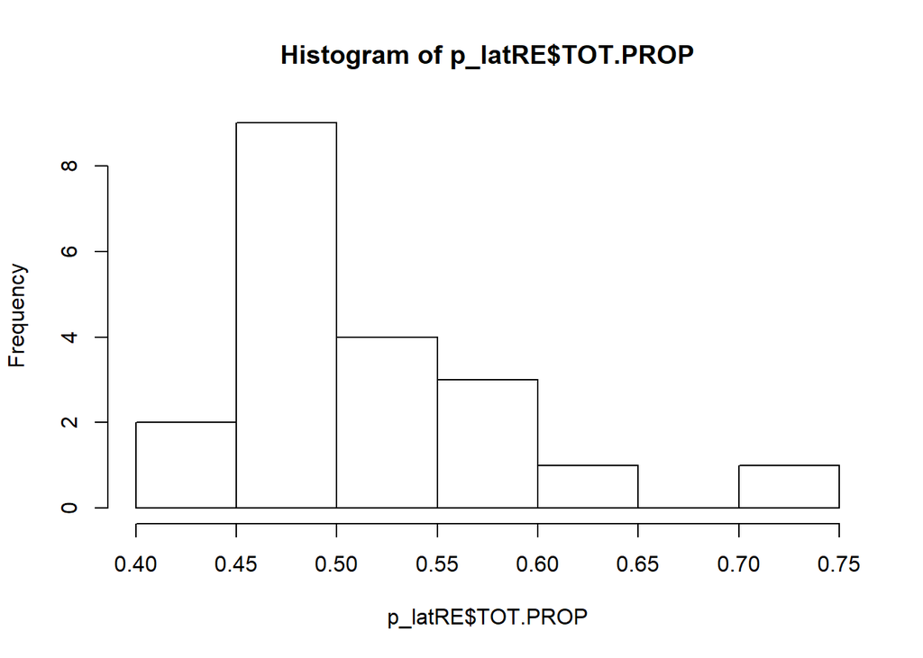

```r
hist(p_latRE$TOT.PROP)
```

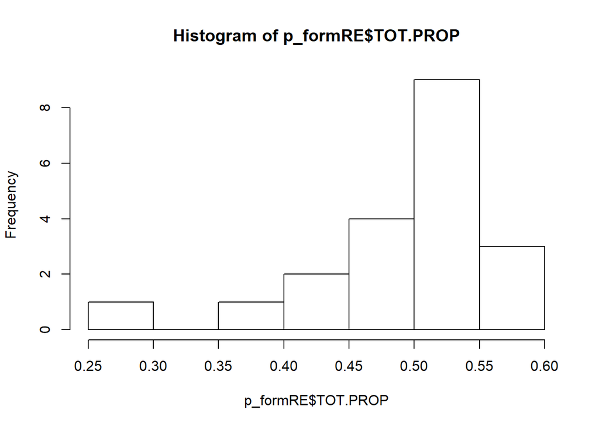

```r
hist(p_formRE$TOT.PROP)
```

- Histogram shows that values aren’t normally distributed; p_form shows an outlier

```r
t.test(p_latRE$TOT.PROP, p_formRE$TOT.PROP)
```

```
##
##  Welch Two Sample t-test
##
## data:  p_latRE$TOT.PROP and p_formRE$TOT.PROP
## t = 0.98655, df = 37.821, p-value = 0.3301
## alternative hypothesis: true difference in means is not equal to 0
## 95 percent confidence interval:
##  -0.02234789  0.06482187
## sample estimates:
## mean of x mean of y
## 0.5122196 0.4909826
```

- T test may not be correct test, as it compares means and not variances. Still, not significant differences.
- Will now do F-test: this will compare the variances of the two data sets.

```r
#two-sided is predicting that the variances could be either greater or less
var.test(p_latRE$TOT.PROP, p_formRE$TOT.PROP, alternative = "two.sided")
```

```
##
##  F test to compare two variances
##
## data:  p_latRE$TOT.PROP and p_formRE$TOT.PROP
## F = 0.87122, num df = 19, denom df = 19, p-value = 0.7669
## alternative hypothesis: true ratio of variances is not equal to 1
## 95 percent confidence interval:
##  0.3448384 2.2010879
## sample estimates:
## ratio of variances
##          0.8712174
```

```r
#greater is predicting that variance of p.lat will be greater than p.form
var.test(p_latRE$TOT.PROP, p_formRE$TOT.PROP, alternative = "greater")
```

```
##
##  F test to compare two variances
##
## data:  p_latRE$TOT.PROP and p_formRE$TOT.PROP
## F = 0.87122, num df = 19, denom df = 19, p-value = 0.6165
## alternative hypothesis: true ratio of variances is greater than 1
## 95 percent confidence interval:
##  0.4018064       Inf
## sample estimates:
## ratio of variances
##          0.8712174
```

```r
#less is predicting that variance of p.lat will be less than p.form
var.test(p_latRE$TOT.PROP, p_formRE$TOT.PROP, alternative = "less")
```

```
##
##  F test to compare two variances
##
## data:  p_latRE$TOT.PROP and p_formRE$TOT.PROP
## F = 0.87122, num df = 19, denom df = 19, p-value = 0.3835
## alternative hypothesis: true ratio of variances is less than 1
## 95 percent confidence interval:
##  0.000000 1.889018
## sample estimates:
## ratio of variances
##          0.8712174
```

- none show anything significant. This could be do to the fact that F test assumes normally distributed data. Can try transforming the data or Levene’s test (last section).

#### Outlier tests

- Histogram shows what appear to be outliers in both species. Will now perform a Tukey’s outlier test to see if they are in fact outlier, and if removing these outliers changes the variance between species.

```r
library(DescTools)
```

```r
Outlier(p_latRE$TOT.PROP, method=c("boxplot"), value = FALSE)
```

```
## integer(0)
```

```r
  #no outliers

Outlier(p_formRE$TOT.PROP, method =c("boxplot"), value = FALSE)
```

```
## [1]  2  3 11 19
```

```r
  #outliers at row 2, 3, 11, 19

(PF_outliers <- p_formRE[c(2,3,11,19),])
```

```
##    X.U.FEFF.SPP     NAME     A.PROP    B.PROP  TOT.PROP  AVG.PROP
## 22       P.form    Maeve 0.45744681 0.4354839 0.4471698 0.4464653
## 23       P.form  Cayenne 0.46315789 0.3321678 0.3975482 0.3976629
## 31       P.form Gretchen 0.01689189 0.5017301 0.2564103 0.2593110
## 39       P.form    Sofia 0.37457045 0.4793103 0.4268503 0.4269404
```

Looks like there are four outlier in the formosa data, but no outliers in the latipinna data.

- I will create a new dataframe without these rows, and test for eye preference and compare variation again.

```r
PFORM_RE <- p_formRE[-c(2,3,11,19),]

# test for eye preference

t.test(PFORM_RE$TOT.PROP, mu=0.5, alternative = "two.sided")
```

```
##
##  One Sample t-test
##
## data:  PFORM_RE$TOT.PROP
## t = 2.5322, df = 15, p-value = 0.02299
## alternative hypothesis: true mean is not equal to 0.5
## 95 percent confidence interval:
##  0.5028851 0.5335741
## sample estimates:
## mean of x
## 0.5182296
```

```r
# comparing species variances

#two-sided is predicting that the variances could be either greater or less
var.test(p_latRE$TOT.PROP, PFORM_RE$TOT.PROP, alternative = "two.sided")
```

```
##
##  F test to compare two variances
##
## data:  p_latRE$TOT.PROP and PFORM_RE$TOT.PROP
## F = 5.2036, num df = 19, denom df = 15, p-value = 0.002202
## alternative hypothesis: true ratio of variances is not equal to 1
## 95 percent confidence interval:
##   1.876498 13.618433
## sample estimates:
## ratio of variances
##             5.2036
```

```r
#greater is predicting that variance of p.lat will be greater than p.form
var.test(p_latRE$TOT.PROP, PFORM_RE$TOT.PROP, alternative = "greater")
```

```
##
##  F test to compare two variances
##
## data:  p_latRE$TOT.PROP and PFORM_RE$TOT.PROP
## F = 5.2036, num df = 19, denom df = 15, p-value = 0.001101
## alternative hypothesis: true ratio of variances is greater than 1
## 95 percent confidence interval:
##  2.223932      Inf
## sample estimates:
## ratio of variances
##             5.2036
```

```r
#less is predicting that variance of p.lat will be less than p.form
var.test(p_latRE$TOT.PROP, PFORM_RE$TOT.PROP, alternative = "less")
```

```
##
##  F test to compare two variances
##
## data:  p_latRE$TOT.PROP and PFORM_RE$TOT.PROP
## F = 5.2036, num df = 19, denom df = 15, p-value = 0.9989
## alternative hypothesis: true ratio of variances is less than 1
## 95 percent confidence interval:
##   0.00000 11.62517
## sample estimates:
## ratio of variances
##             5.2036
```

By removing the outliers, I get significant results.

- For lateralized vision: the p value is now significant, and the mean is 0.5182296; this suggests that the amazons are slightly left-eye lateralized for viewing conspecifics.
- For variance comparison: by removing the outliers, the results show a higher amount of variation in sailfins as compared to amazons.

#### Will create boxplots using both the original, and outlier-removed data

- Will combine the total preference scores of both original and outlier-removed data into one dataset in order to use ggplot more easily.

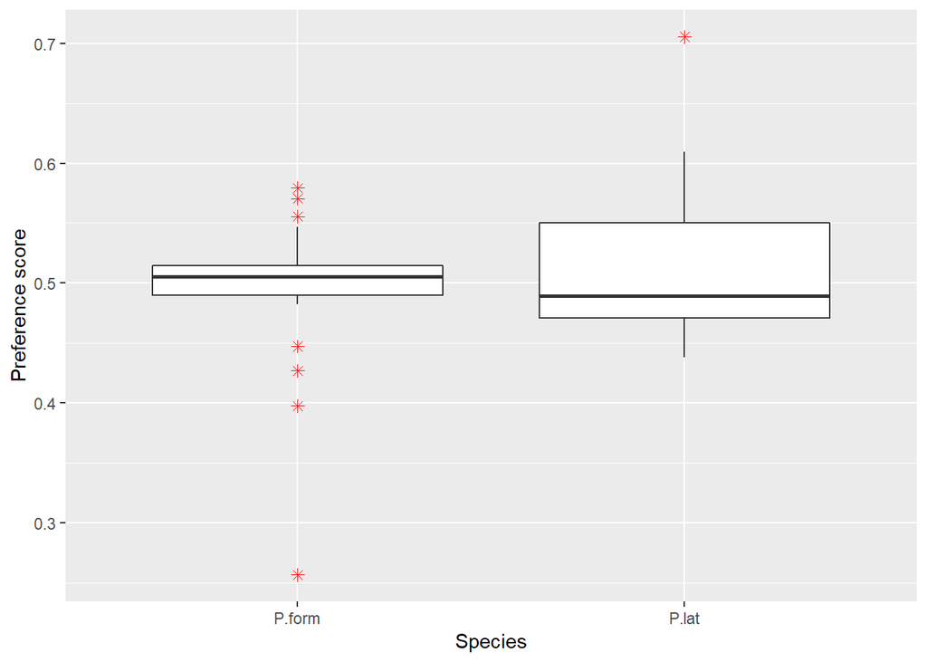

```r
library(ggplot2)
OG_pref_RE <- rbind(p_latRE, p_formRE)

OR_pref_RE <- rbind(p_latRE, PFORM_RE)

ggplot(OG_pref_RE, aes(x=X.U.FEFF.SPP, y=TOT.PROP)) + geom_boxplot(outlier.colour = "red", outlier.shape = 8, outlier.size = 2) + xlab("Species") + ylab("Preference score")
```

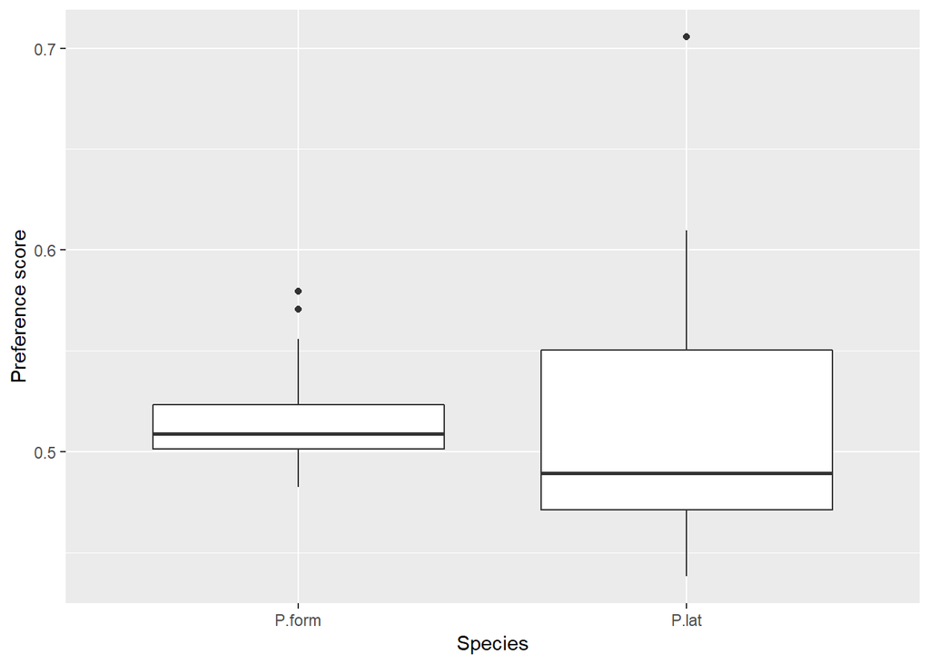

```r
ggplot(OR_pref_RE, aes(x=X.U.FEFF.SPP, y=TOT.PROP)) + geom_boxplot() + xlab("Species") + ylab("Preference score")
```

#### The following section deals with data transformation:

Will transform data to stablize variances/normalize data. - proportions are limited by range of 0-1; transformation will expand this range. - logit transformation (log[p/(1-p)]): expands range from -inf to +inf, but if proportions are 0% or 100% could cause inf to show up in analyses. - arcsine transformation (arcsin[sqrt(p)]): still has a limit (0-pi), but is expanded from original proportion range. - MAY WANT TO INCLUDE WARTON AND HUI PAPER ON TRANSFORMATION ISSUES

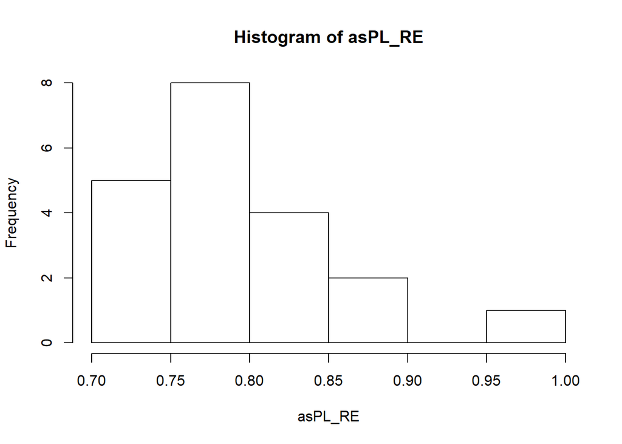

```r
#arcsine function

arcsine <- function(p) {
  asin(sqrt(p))
}

#tranformation of scores only
asPL_RE <- arcsine(p_latRE$TOT.PROP)
asPF_RE <- arcsine(p_formRE$TOT.PROP)

hist(asPL_RE)
```

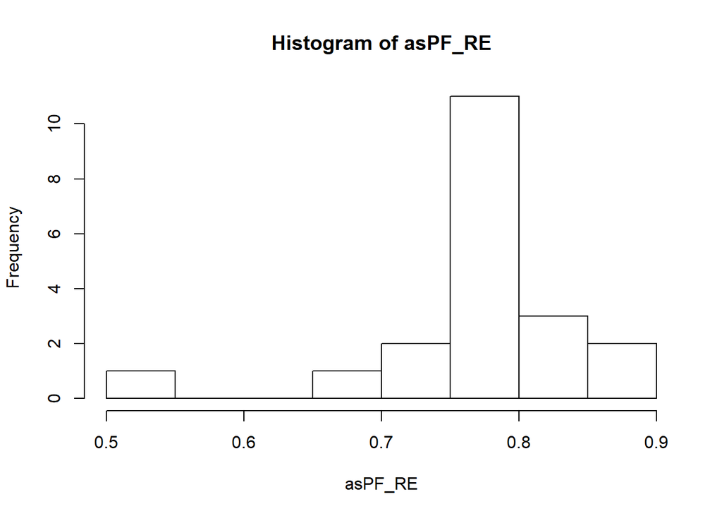

```r
hist(asPF_RE)
```

```r
var.test(asPL_RE, asPF_RE, alternative = "greater")
```

```
##
##  F test to compare two variances
##
## data:  asPL_RE and asPF_RE
## F = 0.85102, num df = 19, denom df = 19, p-value = 0.6356
## alternative hypothesis: true ratio of variances is greater than 1
## 95 percent confidence interval:
##  0.3924907       Inf
## sample estimates:
## ratio of variances
##          0.8510186
```

```r
var.test(asPF_RE, asPL_RE, alternative = "greater")
```

```
##
##  F test to compare two variances
##
## data:  asPF_RE and asPL_RE
## F = 1.1751, num df = 19, denom df = 19, p-value = 0.3644
## alternative hypothesis: true ratio of variances is greater than 1
## 95 percent confidence interval:
##  0.5419401       Inf
## sample estimates:
## ratio of variances
##           1.175062
```

- Not really sure if the var test for greater is testing if y is greater than x, or if x is greater than y, so not sure how to interpret. Either way, it’s not significant.

```r
#logit transformation
library (car)
```

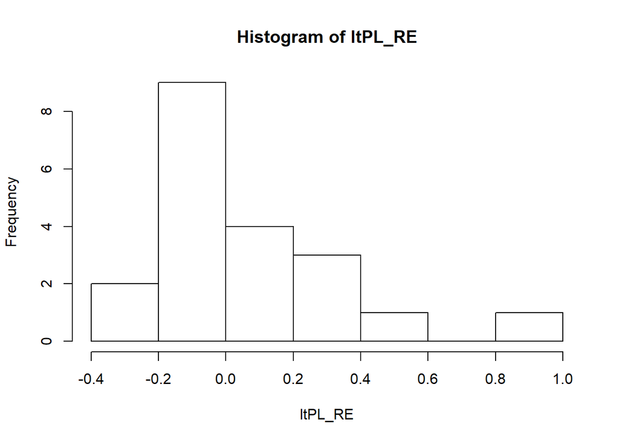

```r
ltPL_RE <- logit(p_latRE$TOT.PROP)
ltPF_RE <- logit(p_formRE$TOT.PROP)

hist(ltPL_RE)
```

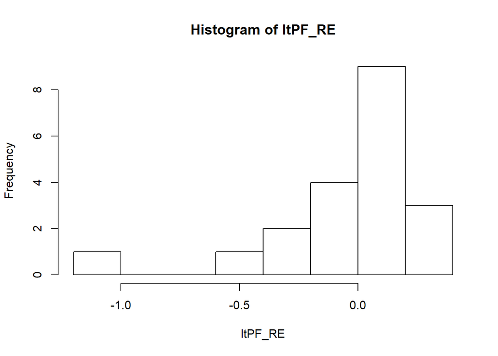

```r
hist(ltPF_RE) #need to adjust range
```

```r
var.test(ltPL_RE, ltPF_RE, alternative = "greater")
```

```
##
##  F test to compare two variances
##
## data:  ltPL_RE and ltPF_RE
## F = 0.82962, num df = 19, denom df = 19, p-value = 0.656
## alternative hypothesis: true ratio of variances is greater than 1
## 95 percent confidence interval:
##  0.3826213       Inf
## sample estimates:
## ratio of variances
##          0.8296193
```

```r
var.test(ltPF_RE, ltPL_RE, alternative = "greater")
```

```
##
##  F test to compare two variances
##
## data:  ltPF_RE and ltPL_RE
## F = 1.2054, num df = 19, denom df = 19, p-value = 0.344
## alternative hypothesis: true ratio of variances is greater than 1
## 95 percent confidence interval:
##  0.555919      Inf
## sample estimates:
## ratio of variances
##           1.205372
```

- Still showing no significance. This transformation still doesn’t help with normality. Not sure if this is something I need to be so concerned about.

```r
#transformation of occurance data then recalculating score
  #first need to sort raw data for species

PL_rawRE <- rawRE[rawRE$X.U.FEFF.SPP == "P.lat",]
PF_rawRE <- rawRE[rawRE$X.U.FEFF.SPP == "P.form",]


PL_rawRE <- transform(PL_rawRE, acLeft = arcsine(PL_rawRE$TOT.LEFT))
```

- This works, in the sense of adding a new column to the existing dataframe with an applied funtion BUT arcsine of any number greater than pi will give a NA (which is what is happening here)
- Will now try Levene’s test. This is similar to the F-test in the sense that it is comparing variances, but it does not assume normality.

```r
#will first try with original data
leveneTest(prefRE$TOT.PROP, prefRE$X.U.FEFF.SPP, center=mean)
```

```
## Levene's Test for Homogeneity of Variance (center = mean)
##       Df F value Pr(>F)
## group  1  0.1486  0.702
##       38
```

```r
#to perform levene test on transformed data, need to add to pref data table first; if not will get following error: error in comlete cases: not all arguments have same length
```